# Zambia Potential Yield Grids

Lyndon Estes

December 3, 2015

# 1 Prepare Maize and Soy Yield Grids

Based on simulated potential yields run by Di Tian.

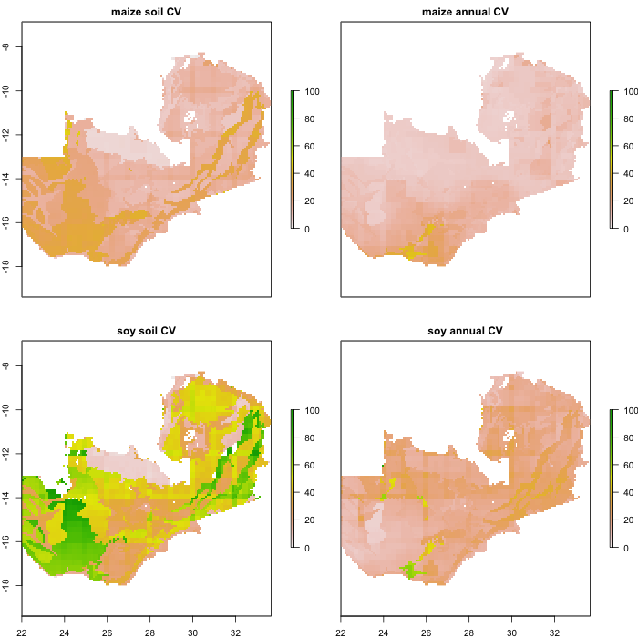

```r
library(agroEcoTradeoff)
# library(data.table)
library(lmisc)
# library(dtraster)
# devtools::install_github("PrincetonUniversity/lmisc")

p_root <- lmisc::set_base_path()
p_crop <- "~/Dropbox/data/agricultural/zambia/dssat/"
p_cropmod <- "~/Dropbox/projects/rCropMod/external/ext_data/"
p_agro <- "~/Dropbox/projects/agroEcoTradeoff/external/base_data/"
p_yield <- full_path(p_root, "external/input_devel/yield")
p_cropland <- full_path(p_root, "external/input_devel/cropland")
p_fao <- "~/Dropbox/data/agricultural/fao/aez/soybean/"

# Read in spatial reference grid and chop it down to size
ID <- fread(full_path(p_crop, "Soil_clim_match_ID_master.csv"))
ID[, V1 := NULL]
setkeyv(ID, c("WTH", "SOL", "Zone"))
ID[, SharePct := as.numeric(SharePct)]
IDr <- subset(unique(ID[, .(x, y, WTH, Zone)]))
setkeyv(IDr, c("WTH", "Zone"))
# unique(ID[, .(WTH, SOL)])
# gr <- dt_to_raster(IDr[, .(ID, x, y)], CRS(prj))
# plot(gr)

prj <- paste0("+proj=aea +lat_1=20 +lat_2=-23 +lat_0=0 +lon_0=25 +x_0=0 +y_0=0",
              " +ellps=WGS84 +towgs84=0,0,0,0,0,0,0 +units=m +no_defs")
gcs <- "+proj=longlat +datum=WGS84"
plot(dt_to_raster(IDr[, .(x, y, as.factor(Zone))], CRS(prj)))

# Maize yield in each grid cell varies as a function of soil, year, and
# management inputs
# Need to capture that uncertainty
# Start with climate uncertainty by mean soil.
# Then look at uncertainty in average year by soil type

# Weighted variance functions, from here:
# https://rulesofreason.wordpress.com/2012/02/13/weighted-variance-and-weighted-coefficient-of-variation/
weighted.var <- function(x, w, na.rm = FALSE) {
    if (na.rm) {
        w <- w[i <- !is.na(x)]
        x <- x[i]
    }
    sum.w <- sum(w)
    sum.w2 <- sum(w^2)
    mean.w <- sum(x * w) / sum(w)
    (sum.w / (sum.w^2 - sum.w2)) * sum(w * (x - mean.w)^2, na.rm = na.rm)
}

weighted.var2 <- function(x, w, na.rm = FALSE) {
  if (na.rm) {
    w <- w[i <- !is.na(x)]
    x <- x[i]
  }
  sum.w <- sum(w)
  (sum(w*x^2) * sum.w - sum(w*x)^2) / (sum.w^2 - sum(w^2))
}

# We're going to start by mapping the CV of the soil versus the inter-annual
# variability in the data, just to the 0.25 degree resolution
# read in different grids, start with Maize
crops <- dir(p_crop, pattern = "maize|soybean", full.names = FALSE)
cv_rasts <- lapply(crops, function(X) {
  # X <- crops[2]
  fnms <- dir(full_path(p_crop, X), pattern = X)
  fl <- unlist(lapply(c("S", "R", "I"), function(x) {
    fnms[grep(paste0(paste0(x, "0"), "|", paste0(x, "9")), fnms)]
  }))  # reorder to read subsistence first
  idt <- copy(IDr)

  # idt[, zoneid := rep(0, nrow(idt))]
  # for(i in 1:length(unique(idt$Zone))) {
  #  idt[Zone == unique(idt$Zone)[i], zoneid := i]
  # }

  for(y in 1:length(fl)) { # y <- 3
    print(paste("Processing", fl[y]))
    cr <- fread(input = full_path(p_crop, paste0(X, "/", fl[y])))
    cr[, "YR" := RUNNO - min(RUNNO) + 1, by = .(TNAM, Zones)]  # unique year
    # crss <- cr[YR == 1, ]
    setnames(cr, c("SOIL_ID...", "WSTA....", "Zones"), c("SOL", "WTH", "Zone"))
    cr[, WTH := substr(WTH, 1, 4)]
    cr[, c("V1", "TRNO") := NULL]
    setkeyv(cr, c("WTH", "SOL", "Zone"))

    crm <- cr[ID[, .(WTH, SOL, SharePct, Zone)], allow.cartesian = TRUE]

    # CV due to interannual variability
    solmu <- crm[, round(weighted.mean(HWAH, w = SharePct)),
                 by = .(WTH, Zone, YR)]

    snm <- gsub("*.*_|\\.csv", "", fl[y])
    anncv <- solmu[, round(cv(V1)), by = .(WTH, Zone)]
    setnames(anncv, "V1", paste0("acv", snm))
    idt <- idt[anncv]
    setkeyv(idt, c("WTH", "Zone"))

    # CV due to soil
    annmu <- crm[, round(mean(HWAH)), by = .(WTH, SOL, Zone, SharePct)]
    annsolmu <- annmu[, weighted.mean(V1, SharePct), by = .(WTH, Zone)]
    solcv <- annmu[, sqrt(weighted.var(V1, w = SharePct, na.rm = TRUE)),
                   by = .(WTH, Zone)][, V1 / annsolmu[, V1] * 100]
    scvnm <- paste0("scv", snm)
    annsolmu[, c(scvnm) := round(solcv)]
    annsolmu[, V1 := NULL]
    setkeyv(annsolmu, c("WTH", "Zone"))
    idt <- idt[annsolmu]
    setkeyv(idt, c("WTH", "Zone"))
    idt
  }
  idt
})
names(cv_rasts) <- crops

# Mean CVs by cultivar
mucvs <- lapply(crops, function(x) {
  cv_rasts[[x]][, lapply(.SD, function(x) mean(x, na.rm = TRUE)),
                 .SDcols = grep("cv", names(cv_rasts[[x]]))]
})
# cv_rasts$soybean[, lapply(.SD, function(x) length(which(is.na(x)))),
#                  .SDcols = grep("cv", names(cv_rasts$soybean))]  # only 2 nas
# plot(sapply(nms1, function(x) mucvs[[1]][, get(x)]),
#      sapply(nms2, function(x) mucvs[[1]][, get(x)]))

# Calculate mean CV across cultivar types
dtr <- lapply(crops, function(x) {
  nms1 <- names(cv_rasts[[x]])[grep("scv", names(cv_rasts[[x]]))]
  nms2 <- names(cv_rasts[[x]])[grep("acv", names(cv_rasts[[x]]))]
  cv_rasts[[x]][,  scvmu := rowMeans(.SD, na.rm = TRUE), .SDcols = nms1]
  cv_rasts[[x]][,  acvmu := rowMeans(.SD, na.rm = TRUE), .SDcols = nms2]
  dt_to_raster(cv_rasts[[x]][, .(x, y, scvmu, acvmu)], CRSobj = gcs)
})

# cv_rasts[[1]][order(x, -y), .(x, y)]

# CV due to soil and climate
png(full_path(p_root, "external/input_devel/crop-cv.png"), width = 700,
    height = 700)
plot(stack(dtr), zlim = c(0, 100),
     main = c("maize soil CV", "maize annual CV", "soy soil CV",
              "soy annual CV"))
dev.off()
```

These maps display the coefficient of variation in simulated maize (top row) and soybean (bottom row) yields, for variability due to soil differences (left column) and inter-annual variability in weather (right column). Soil differences within a given grid cause more yield variability than seasonal differences in weather.

Back to top

# 2 Yield grids

## 2.1 10 km grids

Creating 10 km grids for 10th, 50th, 90th percentile yields for each cultivar under each management type (subsistence, rainfed commercial, irrigated).

```r
nmso <- c("10", "50", "90")  # naming vector for quantile variables
probs <- c(0.1, 0.5, 0.9)  # quantiles to get
crops <- list.dirs(p_crop, full.names = FALSE)[-1]  # dir names
yld_rasts <- lapply(crops, function(X) {
  # X <- crops[1]
  fnms <- dir(full_path(p_crop, X))
  fl <- unlist(lapply(c("S", "R", "I"), function(x) {
    fnms[grep(paste0(paste0(x, "0"), "|", paste0(x, "9")), fnms)]
  }))  # reorder to read subsistence first
  idt <- copy(IDr)
  for(y in 1:length(fl)) { # y <- 1
    print(paste("Processing", fl[y]))
    cr <- fread(input = full_path(p_crop, paste0(X, "/", fl[y])))
    cr[, "YR" := RUNNO - min(RUNNO) + 1, by = .(TNAM, Zones)]  # unique year
    setnames(cr, c("SOIL_ID...", "WSTA....", "Zones"), c("SOL", "WTH", "Zone"))
    cr[, WTH := substr(WTH, 1, 4)]
    cr[, c("V1", "TRNO") := NULL]
    setkeyv(cr, c("WTH", "SOL", "Zone"))

    # merge IDs
    crm <- cr[ID[, .(WTH, SOL, SharePct, Zone)], allow.cartesian = TRUE]

    # Soil averaged yields
    solmu <- crm[, round(weighted.mean(HWAH, w = SharePct)),
                 by = .(WTH, Zone, YR)]
    snm <- gsub("*.*_|\\.csv", "", fl[y])

    # Yield quantiles and means
    for(i in 1:3) {
      # solmu[WTH == "AAAA" & Zone == "Zone2b", box_stats(V1), by = .(WTH, Zone)]
      v <- solmu[, quantile(V1, probs = probs[i]), by = .(WTH, Zone)]
      setnames(v, "V1", paste0("y", nmso[i], "_", snm))
      idt <- idt[v]
      setkeyv(idt, c("WTH", "Zone"))
    }
    v <- solmu[, round(mean(V1)), by = .(WTH, Zone)]
    setnames(v, "V1", paste0("ymu_", snm))
    idt <- idt[v]
    setkeyv(idt, c("WTH", "Zone"))
    idt
  }
  idt
})
names(yld_rasts) <- crops

# Write out 10 km yield grids to csvs, for safe keeping
lapply(crops, function(x) {
  fnm <- full_path(p_root,
                   paste0("external/data/", x, "_yields_10km.csv"))
  write.csv(yld_rasts[[x]], file = fnm, row.names = FALSE)
})
yld_rasts <- lapply(crops, function(x) {
  fnm <- full_path(p_root,
                   paste0("external/data/", x, "_yields_10km.csv"))
  fread(fnm)
})
names(yld_rasts) <- crops

# Take average of mean yields across the different cultivar types.
# This will give 1 set of yields for each of the three management scenarios
# Subsistence, rainfed commercial, irrigated
# The same approach can be used to estimate the average of the 10th percentile
# across cultivars, or median, or 90th, etc.

# fill in yield at edges
yield_fix <- function(x = r[[1]], w, na.rm = TRUE) {
  r <- focal(x, w = w, fun = mean, na.rm = na.rm)
  rmsk <- (!is.na(r) & is.na(x)) * r
  x[is.na(x)] <- 0
  rfix <- x + rmsk  # add back in edge bits
}

# ra
w <- matrix(ncol = 3, nrow = 3, rep(1, 9))
yld_rl <- lapply(crops, function(x) {  # x <- crops[[1]]
  yr <- lapply(c("S", "R", "I"), function(y) {  # y <- "S"
    ylds <- yld_rasts[[x]]
    nms <- names(ylds)
    cnms <- nms[grep(paste0("y.*._", y), nms)]
    r <- dt_to_raster(ylds[, c("x", "y", cnms), with = FALSE], CRSobj = CRS(gcs))
    rfoc <- sapply(1:nlayers(r), function(i) rfoc <- yield_fix(r[[i]], w = w))
    names(rfoc) <- names(r)
    rs <- stack(rfoc)
    rs
  })
  named_out(yr, c("S", "R", "I"))
})
names(yld_rl) <- crops

# cellStats(yld_rl$maize$R[["ymu_R0002"]], mean)
# plot(yld_rl$maize$R[["y50_R0002"]])
```

## 2.2 Yield bias correction

### 2.2.1 Soybean fix based on GAEZ data

Potential soybean yields are too low for Zambia, so we will adjust them up with FAO-GAEZ yields. This doesn’t seem necessary for maize, because our potential yield averages are at or below the GYGA rainfed yield potentials.

```r
cellStats(yld_rl$maize$I[["ymu_I0004"]], mean)
plot(yld_rl$maize$R[["ymu_R0002"]])
plot(yld_rl$maize$S[["ymu_S0002"]])
```

This is one approach for bias-correction.

```r
faonms <- dir(p_fao, full.names = TRUE)
file.rename(faonms, gsub("res02crav6190|yld_package", "", faonms))
faonms <- dir(p_fao, full.names = TRUE)
p_faosoy <- full_path(p_fao, c("soybean_I", "soybean_R", "soybean_S"))
file.rename(faonms, full_path(p_fao, c("soybean_I", "soybean_R", "soybean_S")))
faonms <- dir(p_faosoy, full.names = TRUE)
renm <- paste0(p_faosoy, c("soybean_I", "soybean_R", "soybean_S"), ".tif")
file.rename(faonms[grep("res02_crav6190", faonms)], renm)

# load in tiffs, crop and mask to Zambia
faosoy <- lapply(renm, function(x) raster(x))
names(faosoy) <- c("soybean_I", "soybean_R", "soybean_S")
faosoy <- lapply(faosoy, function(x) {
  r <- crop(x, yld_rl$soybean$S)
  ro <- mask(r, yld_rl$soybean$S[[1]])
})
faosoy <- faosoy[names(faosoy)[3:1]]  # rearrange
plot(faosoy[[2]])

# dssat soy mean yield grids
dssatsoy_mu <- sapply(yld_rl$soybean, function(x) {
  r <- calc(x[[grep("ymu", names(x))]], mean)
})
sapply(dssatsoy_mu, function(x) cellStats(x, mean))

# Find mean yield differences
soydiff <- lapply(1:3, function(x) {
  faosoy[[x]] - dssatsoy_mu[[x]]
})
soydiffmsk <- lapply(soydiff, function(x) x < 0) # poss and negative

# Liuwa plains and wetland yields much higher than should be. Don't adjust

bias <- sapply(1:3, function(x) {
  r1 <- mask(soydiff[[x]], soydiffmsk[[x]] == 0, maskvalue = 0)
  r2 <- mask(soydiff[[x]], soydiffmsk[[x]] == 1, maskvalue = 0)
  c("mu1" = cellStats(r1, mean), "mu2" = cellStats(r2, mean),
    "med1" =  quantile(r1, probs = 0.5), "med2" =  quantile(r2, probs = 0.5))
})

# calculate bias offset for different management types, filtering out wetland
# areas. Interpolate between rainfed subsistence and commercial because of
# of overly high (3,500 kg/ha) rainfed high input bias
biasu <- bias[c(1, 3), ]
biasu[, 2] <- rowMeans(bias[c(1, 3), c(1, 3)]) # replace with interpolated
biasd <- bias[c(2, 4), ]  # down adjustment for wetlands
biasd[, 2] <- rowMeans(bias[c(2, 4), c(1, 3)]) # replace with interpolated

# median and mean bias about the same
# fix dssat yields, test first on just the mean yields
par(mfrow = c(2, 2))
soyadjtest <- lapply(1:3, function(x) {  # x = 1
  r1 <- (dssatsoy_mu[[x]] + biasu[2, x]) * (soydiffmsk[[x]] == 0)
  r2 <- (dssatsoy_mu[[x]]) * (soydiffmsk[[x]] == 1)
  r3 <- r1 + r2
  plot(r3)
})

# Fix all of them now
soyfix <- lapply(1:3, function(x) {
  ri <- yld_rl$soybean[[x]]
  r1 <- (ri + biasu[2, x]) * (soydiffmsk[[x]] == 0)
  r2 <- ri * (soydiffmsk[[x]] == 1)
  r3 <- r1 + r2
  names(r3) <- names(ri)
  r3
})
names(soyfix) <- names(yld_rl$soybean)
```

```r
yld_rl2 <- list(yld_rl$maize, soyfix)
names(yld_rl2) <- crops

for(i in 1:length(yld_rl2)) {
  rl <- yld_rl2[[i]]
  for(j in 1:length(rl)) {
    fnm <- full_path(p_yield, paste0(crops[i], "_", names(rl)[j], "_10K.tif"))
    writeRaster(rl[[j]], filename = fnm, overwrite = TRUE)
    layernms <- names(rl[[j]])
    save(layernms, file = gsub("\\.tif", "\\.rda", fnm))
  }
}
```

Back to top

## 2.3 How to make 1 km grids/data.tables

This provides the methods for taking 10 km grids, averaging them across cultivars within management treatments, and then resampling to 1 km grids. This is approximately the approach that will be used to make inputs for the tradeoff model. Other methods to explore include blending different types of management practice, e.g. X% of each cell is irrigated, Y% is rainfed commercial, Z% is subsistence.

```r
yld_mus <- lapply(crops, function(x) {  # x <- crops[[1]]
  ymu <- lapply(c("S", "R", "I"), function(y) {  #y <- "S"
    cnms <- names(yld_rasts[[x]])[grep(paste0("mu_", y), names(yld_rasts[[x]]))]
    ylds <- copy(yld_rasts[[x]][, c("x", "y", cnms), with = FALSE])
    ylds[, c(x) := round(rowMeans(.SD)), .SDcols = cnms]
    ylds[, c(cnms) := NULL]
    ylds
  })
  named_out(ymu, c("S", "R", "I"))
})
names(yld_mus) <- crops
plot(dt_to_raster(yld_mus[[2]]$R, CRSobj = gcs))

# 1 km resample
mgrid <- raster(full_path(p_agro, "ZA-grid.tif"))
msk <- raster(full_path(p_agro, "ZA-mask.tif"))
lapply(c("S", "R", "I"), function(x) { # x <- "S"
  print(paste("Processing", x))
  DTL <- lapply(crops, function(y) {  # y <- crops[1]
    # fname <- full_path("external/base_data/", paste0(x, "-crop-yields.tif"))
    print(paste("..Processing", y))
    r <- dt_to_raster(yld_mus[[y]][[x]], CRSobj = gcs)
    r2 <- disaggregate(r, fact = 10)
    r3 <- resample(r, r2)
    r4 <- projectRaster(r3, msk)
    r4 <- mask(r4, msk)
    # plot(r4)
    valinds <- which(!is.na(values(msk)))
    DT <- as.data.table.raster(r4, xy = FALSE)[valinds, ]
    DT[, c(y) := round(get(y))]
    DT
  })
  DTdt <- do.call(cbind, DTL)
  fnm <- full_path(p_root,
                   paste0("external/data/ZA-potential-yields-", x, ".csv"))
  write.table(DTdt, file = fnm, sep = ",", col.names = TRUE, row.names = FALSE)
})
```

Back to top

## 2.4 Resulting model inputs

`maize_S|R|I_10K.tif` - 10 km maize grids for different management `soybean_S|R|I_10K.tif` - 10 km soy grids for different management

These will have to go through intermediate, and perhaps on the fly, processing in batch mode to represent different yield scenarios.